# Statistics 418 HW3

Fan Ding (604172042)

May 20th, 2017

Read in Data

```r
set.seed(1)
library(readr)
adult <- read_delim("~/Desktop/adult.txt", " ", escape_double = FALSE, col_names = FALSE, trim_ws = TRUE, skip = 1)
colnames(adult) <- c("id","age","workclass","final_weight","education","education_num","marital_status","occupation","relationship","race","sex","capital_gain","capital_loss","hours_per_week","natice_country","aw_over_50k")
nrow(adult[which(adult$aw_over_50k == 1),])
```

```
## [1] 11687
```

```r
nrow(adult[which(adult$aw_over_50k == 0),])
```

```
## [1] 37155
```

```r
adult <- adult[,-1]
k <- sample(c(1:48842), 34190, replace=FALSE)
adult_train <- adult[k,]
adult_test1 <- adult[-k,]
m <- sample(c(1:14652), 4884, replace=FALSE)
adult_validation <- adult_test1[m,]
adult_test <- adult_test1[-m,]
```

Logistic Regression

```r
set.seed(1)
# use glmnet package
library(glmnet)
library(ROCR)
```

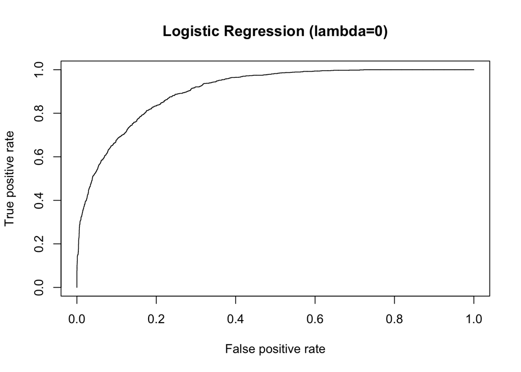

```r
adult_lr <- Matrix::sparse.model.matrix(aw_over_50k~.-1, data = adult)
adult_lr_train <- adult_lr[k,]
adult_lr_t <- adult_lr[-k,]
adult_lr_validation <- adult_lr_t[m,]
adult_lr_test <- adult_lr_t[-m,]
## lambda = 0
lr1 <- glmnet(adult_lr_train, adult_train$aw_over_50k, family = "binomial", lambda = 0)
phat_lr1 <- predict(lr1, newx = adult_lr_validation, type = "response")
rocr_pred_lr1 <- prediction(phat_lr1, adult_validation$aw_over_50k)
perf1 <- performance(rocr_pred_lr1, "tpr", "fpr")
plot(perf1, main="Logistic Regression (lambda=0)", col="black")
```

```r
performance(rocr_pred_lr1, "auc")@y.values[[1]]
```

```
## [1] 0.9053544
```

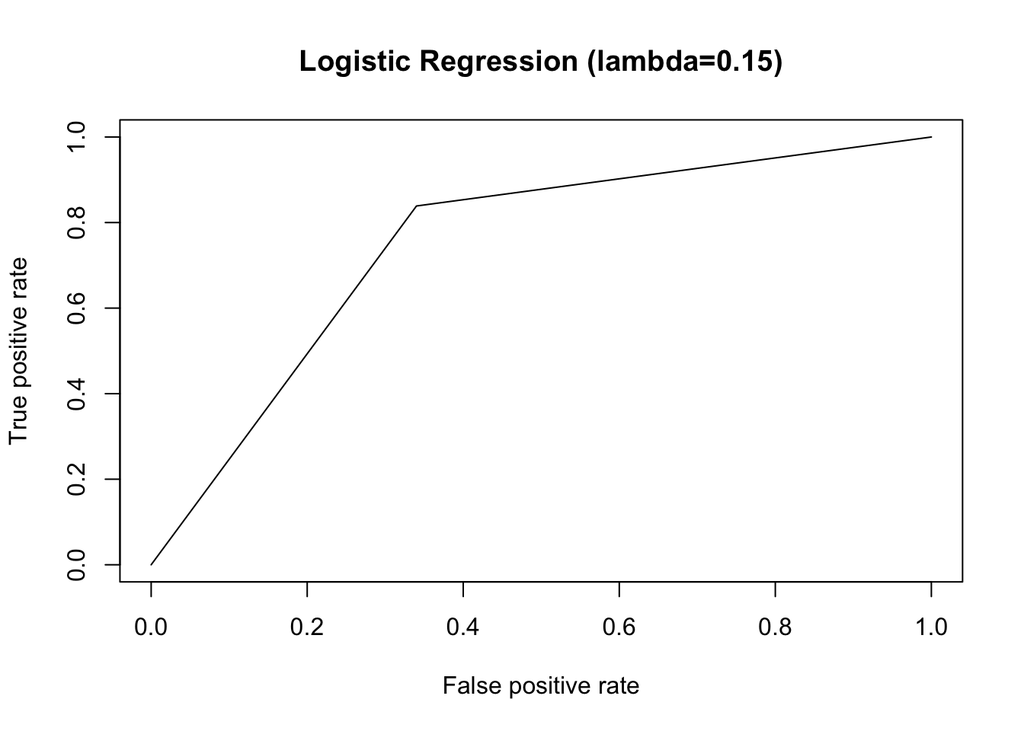

```r
## lambda = 0.15
lr2 <- glmnet(adult_lr_train, adult_train$aw_over_50k, family = "binomial", lambda = 0.15)
phat_lr2 <- predict(lr2, newx = adult_lr_validation, type = "response")
rocr_pred_lr2 <- prediction(phat_lr2, adult_validation$aw_over_50k)
perf2 <- performance(rocr_pred_lr2, "tpr", "fpr")
plot(perf2, main="Logistic Regression (lambda=0.15)", col="black")
```

```r
performance(rocr_pred_lr2, "auc")@y.values[[1]]
```

```
## [1] 0.7493182
```

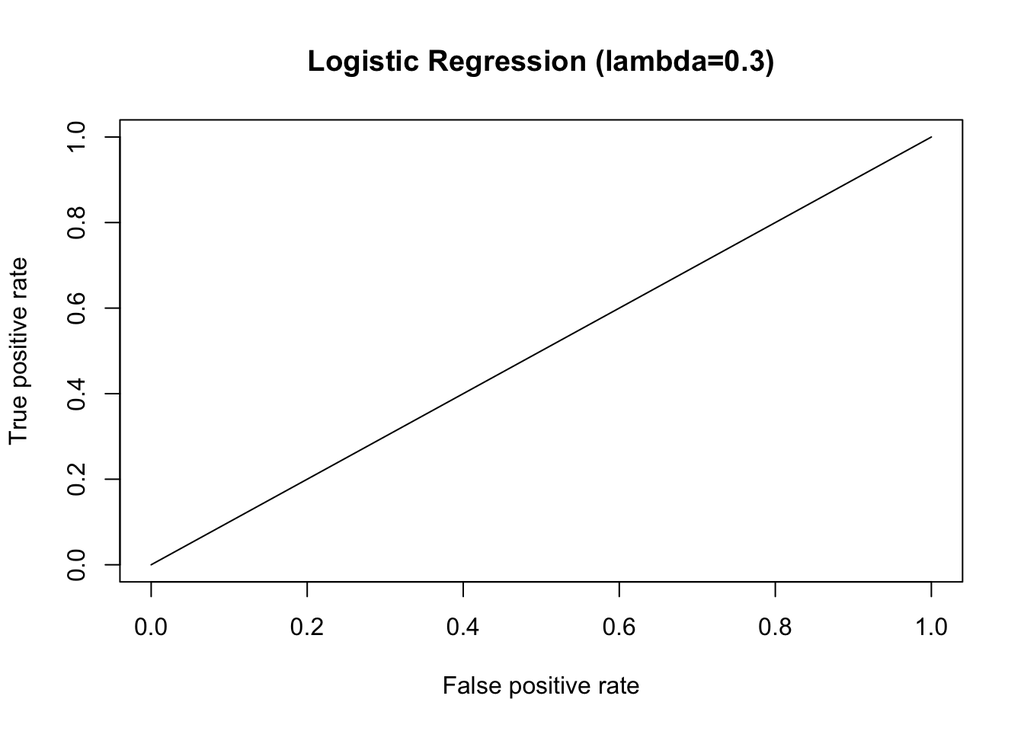

```r
## lambda = 0.3
lr3 <- glmnet(adult_lr_train, adult_train$aw_over_50k, family = "binomial", lambda = 0.3)
phat_lr3 <- predict(lr3, newx = adult_lr_validation, type = "response")
rocr_pred_lr3 <- prediction(phat_lr3, adult_validation$aw_over_50k)
perf3 <- performance(rocr_pred_lr3, "tpr", "fpr")
plot(perf3, main="Logistic Regression (lambda=0.3)", col="black")
```

```r
performance(rocr_pred_lr3, "auc")@y.values[[1]]
```

```
## [1] 0.5
```

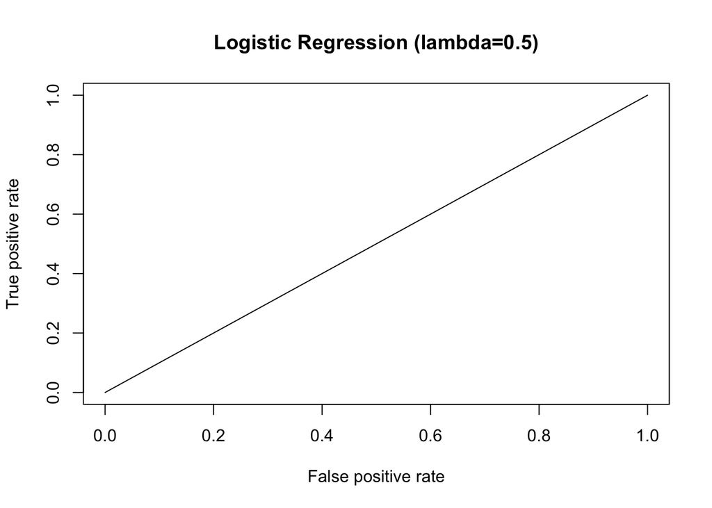

```r
## lambda = 0.5
lr4 <- glmnet(adult_lr_train, adult_train$aw_over_50k, family = "binomial", lambda = 0.5)
phat_lr4 <- predict(lr4, newx = adult_lr_validation, type = "response")
rocr_pred_lr4 <- prediction(phat_lr4, adult_validation$aw_over_50k)
perf4 <- performance(rocr_pred_lr4, "tpr", "fpr")
plot(perf4, main="Logistic Regression (lambda=0.5)", col="black")
```

```r
performance(rocr_pred_lr4, "auc")@y.values[[1]]
```

```
## [1] 0.5
```

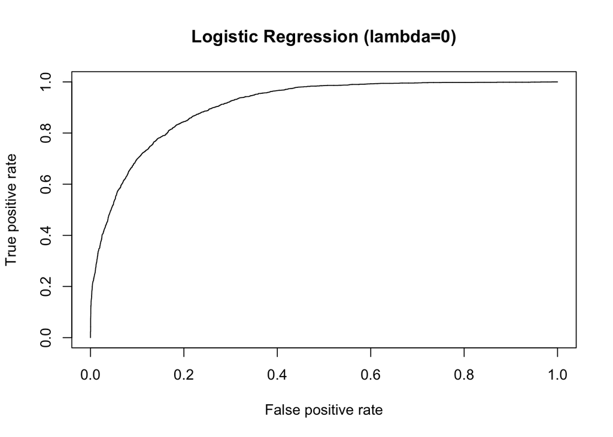

```r
### Any lambda lorger than 0.5 give the auc result of 0.5.

## test data
### Using the validation data, we can tell the auc is the largest when the lambda is 0. So we use the model lr1 to apply to the test data.
phat_lr1_test <- predict(lr1, newx = adult_lr_test, type = "response")
rocr_pred_lr1_test <- prediction(phat_lr1_test, adult_test$aw_over_50k)
perf1_test <- performance(rocr_pred_lr1_test, "tpr", "fpr")
plot(perf1_test, main="Logistic Regression (lambda=0)", col="black")
```

```r
performance(rocr_pred_lr1_test, "auc")@y.values[[1]]
```

```
## [1] 0.9068782
```

```r
## FP, TP trade off: when false positive rate is small, true positive rate is also small. If we increase false positive rate, true positive rate will also increase. When false positive rate becomes 0.3, true positive rate can reach around 0.9 and this is a relatively reasonable level.

# use h2o package
library(h2o)
h2o.init(nthreads=-1)
```

```
##  Connection successful!
##
## R is connected to the H2O cluster:
##     H2O cluster uptime:         4 hours 33 minutes
##     H2O cluster version:        3.10.4.6
##     H2O cluster version age:    27 days
##     H2O cluster name:           H2O_started_from_R_apple_xvi154
##     H2O cluster total nodes:    1
##     H2O cluster total memory:   1.05 GB
##     H2O cluster total cores:    4
##     H2O cluster allowed cores:  4
##     H2O cluster healthy:        TRUE
##     H2O Connection ip:          localhost
##     H2O Connection port:        54321
##     H2O Connection proxy:       NA
##     H2O Internal Security:      FALSE
##     R Version:                  R version 3.3.2 (2016-10-31)
```

```r
adult_lr_h2o <- h2o.importFile("/Users/apple/Desktop/adult.txt")
colnames(adult_lr_h2o) <- c("id","age","workclass","final_weight","education","education_num","marital_status","occupation","relationship","race","sex","capital_gain","capital_loss","hours_per_week","natice_country","aw_over_50k")
adult_lr_h2o <- adult_lr_h2o[,-1]
adult_lr_h2o_split <- h2o.splitFrame(adult_lr_h2o, ratios=c(0.7,0.1))
adult_lr_h2o_train <- adult_lr_h2o_split[[1]]
adult_lr_h2o_validation <- adult_lr_h2o_split[[2]]
adult_lr_h2o_test <- adult_lr_h2o_split[[3]]
adult_lr_h2o_names <- names(adult_lr_h2o_train)[which(names(adult_lr_h2o_train)!="aw_over_50k")]
## lambda = 0
lr1_h2o <- h2o.glm(x=adult_lr_h2o_names, y="aw_over_50k", training_frame=adult_lr_h2o_train, family = "binomial", alpha = 1, lambda = 0)
h2o.auc(h2o.performance(lr1_h2o, adult_lr_h2o_validation))
```

```
## [1] 0.9093765
```

```r
## lambda = 0.1
lr2_h2o <- h2o.glm(x=adult_lr_h2o_names, y="aw_over_50k", training_frame=adult_lr_h2o_train, family = "binomial", alpha = 1, lambda = 0.1)
h2o.auc(h2o.performance(lr2_h2o, adult_lr_h2o_validation))
```

```
## [1] 0.7334554
```

```r
## lambda = 0.15
lr3_h2o <- h2o.glm(x=adult_lr_h2o_names, y="aw_over_50k", training_frame=adult_lr_h2o_train, family = "binomial", alpha = 1, lambda = 0.15)
h2o.auc(h2o.performance(lr3_h2o, adult_lr_h2o_validation))
```

```
## [1] 0.5
```

```r
## lambda = 0.3
lr4_h2o <- h2o.glm(x=adult_lr_h2o_names, y="aw_over_50k", training_frame=adult_lr_h2o_train, family = "binomial", alpha = 1, lambda = 0.3)
h2o.auc(h2o.performance(lr4_h2o, adult_lr_h2o_validation))
```

```
## [1] 0.5
```

```r
### Any lambda lorger than 0.15 give the auc result of 0.5.
### Using the validation data, we can tell the auc is the largest when the lambda is 0. So we use the model lr1_h2o to apply to the test data.
phat_lr1_test_h2o <- h2o.predict(lr1_h2o, adult_lr_h2o_test)
h2o.auc(h2o.performance(lr1_h2o, adult_lr_h2o_test))
```

```
## [1] 0.909266
```

LR Result Interpretation Here I use logistic regression (Lasso regularization) with different paramteter lambda. Lambda controls the overall strength of the penalty. We want AUC to be as large as possible, so that we need to choose a “best” lambda to achieve that. I tried several numbers from 0 to 0.5, and figure out that 0 is the best lambda to use.

Note: AUC Interpretation AUC means area under the curve, and here the curve I use is the ROC curve (Receiver Operating Characteristic curve). Its x-axis is false positive rate, meaning the ratio between number of false positives and total number of predictions. Its y-axis is the true positive rate, meaning the ratio between number of true positives and total number of predictions. It equals to the probability that a classifier will rank a randomly chosen positive instance higher than a randomly chosen negative one. In other words, the larger the AUC, the more accurate the model and the prediction will be. This is the criterion I use to determine the goodness of a model, and to select the final model to use.

Random Forest

```r
set.seed(1)
# use r package
library(randomForest)
adult_train1 <- adult_train
adult_train1[adult_train1 == "?"] <- NA
adult_train1 <- adult_train1[complete.cases(adult_train1),]
adult_train1$workclass <- as.factor(adult_train1$workclass)
adult_train1$education <- as.factor(adult_train1$education)
adult_train1$marital_status <- as.factor(adult_train1$marital_status)
adult_train1$occupation <- as.factor(adult_train1$occupation)
adult_train1$relationship <- as.factor(adult_train1$relationship)
adult_train1$race <- as.factor(adult_train1$race)
adult_train1$sex <- as.factor(adult_train1$sex)
adult_train1$natice_country <- as.factor(adult_train1$natice_country)
adult_train1$aw_over_50k <- as.factor(adult_train1$aw_over_50k)

adult_validation1 <- adult_validation
adult_validation1[adult_validation1 == "?"] <- NA
adult_validation1 <- adult_validation1[complete.cases(adult_validation1),]
adult_validation1$workclass <- as.factor(adult_validation1$workclass)
adult_validation1$education <- as.factor(adult_validation1$education)
adult_validation1$marital_status <- as.factor(adult_validation1$marital_status)
adult_validation1$occupation <- as.factor(adult_validation1$occupation)
adult_validation1$relationship <- as.factor(adult_validation1$relationship)
adult_validation1$race <- as.factor(adult_validation1$race)
adult_validation1$sex <- as.factor(adult_validation1$sex)
adult_validation1$natice_country <- as.factor(adult_validation1$natice_country)
adult_validation1$aw_over_50k <- as.factor(adult_validation1$aw_over_50k)
levels(adult_validation1$natice_country) <- levels(adult_train1$natice_country)

adult_test1 <- adult_test
adult_test1[adult_test1 == "?"] <- NA
adult_test1 <- adult_test1[complete.cases(adult_test1),]
adult_test1$workclass <- as.factor(adult_test1$workclass)
adult_test1$education <- as.factor(adult_test1$education)
adult_test1$marital_status <- as.factor(adult_test1$marital_status)
adult_test1$occupation <- as.factor(adult_test1$occupation)
adult_test1$relationship <- as.factor(adult_test1$relationship)
adult_test1$race <- as.factor(adult_test1$race)
adult_test1$sex <- as.factor(adult_test1$sex)
adult_test1$natice_country <- as.factor(adult_test1$natice_country)
adult_test1$aw_over_50k <- as.factor(adult_test1$aw_over_50k)
levels(adult_test1$natice_country) <- levels(adult_train1$natice_country)

## try various numbers of trees
### 10 trees
rf1 <- randomForest(adult_train1[,c(1:14)], adult_train1$aw_over_50k, ntree=10)
phat1_prob_rf <- predict(rf1, adult_validation1, type="prob")[,"1"]
table(ifelse(phat1_prob_rf > 0.5, 1, 0), adult_validation1$aw_over_50k)
```

```
##
##        0    1
##   0 3398  765
##   1   30  333
```

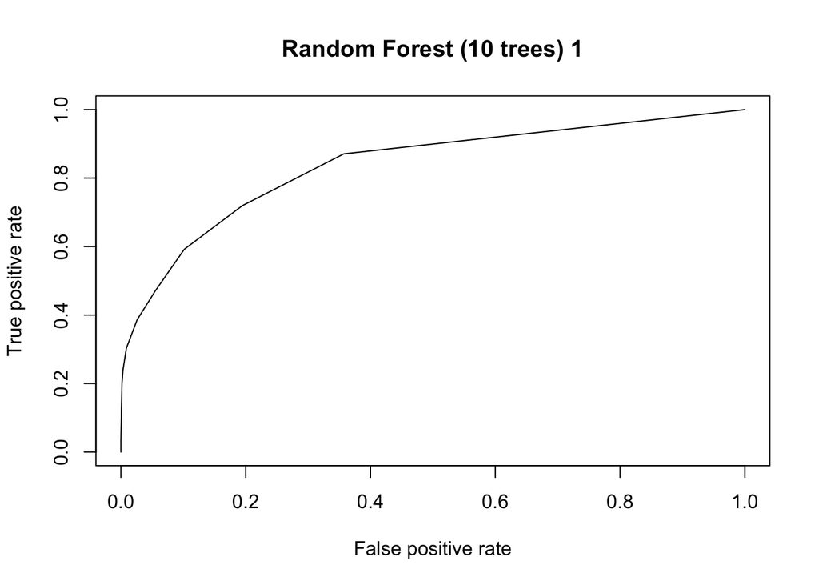

```r
pred1_rf <- prediction(phat1_prob_rf, adult_validation1$aw_over_50k)
plot(performance(pred1_rf, "tpr", "fpr"), main="Random Forest (10 trees) 1")
```

```r
performance(pred1_rf, "auc")@y.values[[1]]
```

```
## [1] 0.836694
```

```r
#### tune the depth of the trees and the mtry
##### maxnodes=4, mtry=5
rf2 <- randomForest(adult_train1[,c(1:14)], adult_train1$aw_over_50k, ntree=10, maxnodes=4, mtry=5)
phat2_prob_rf <- predict(rf2, adult_validation1, type="prob")[,"1"]
table(ifelse(phat2_prob_rf > 0.5, 1, 0), adult_validation1$aw_over_50k)
```

```
##
##        0    1
##   0 3304  616
##   1  124  482
```

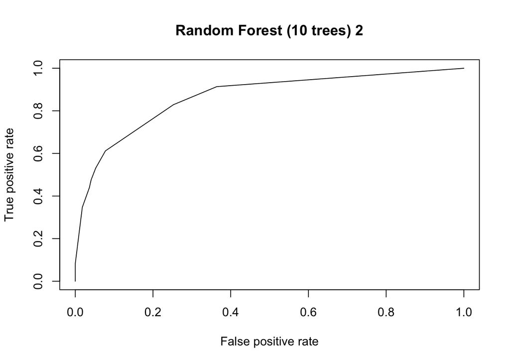

```r
pred2_rf <- prediction(phat2_prob_rf, adult_validation1$aw_over_50k)
plot(performance(pred2_rf, "tpr", "fpr"), main="Random Forest (10 trees) 2")
```

```r
performance(pred2_rf, "auc")@y.values[[1]]
```

```
## [1] 0.8649393
```

```r
##### maxnodes=3, mtry=2
rf3 <- randomForest(adult_train1[,c(1:14)], adult_train1$aw_over_50k, ntree=10, maxnodes=3, mtry=2)
phat3_prob_rf <- predict(rf3, adult_validation1, type="prob")[,"1"]
table(ifelse(phat3_prob_rf > 0.5, 1, 0), adult_validation1$aw_over_50k)
```

```
##
##        0    1
##   0 3428 1098
```

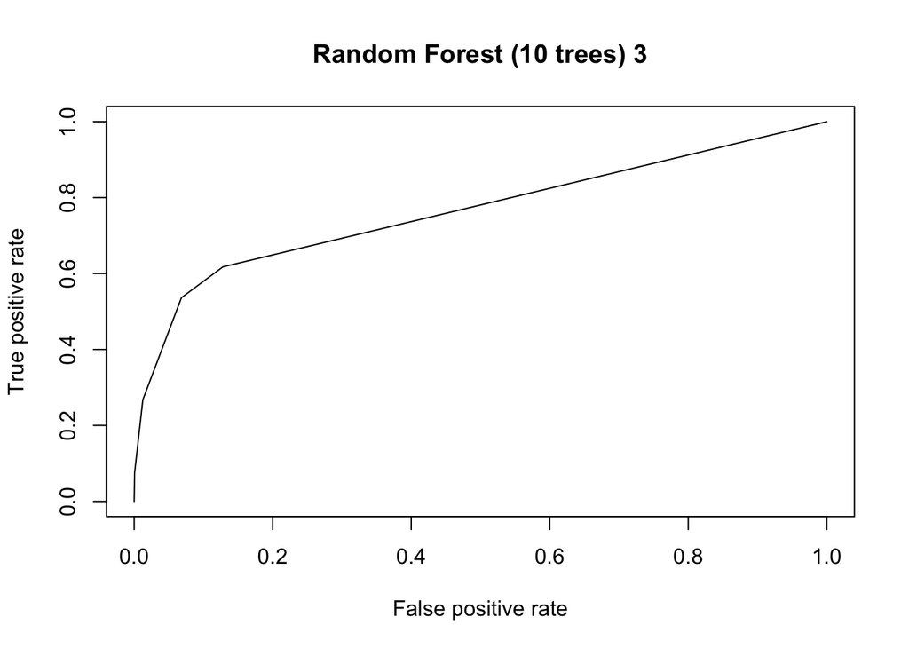

```r
pred3_rf <- prediction(phat3_prob_rf, adult_validation1$aw_over_50k)
plot(performance(pred3_rf, "tpr", "fpr"), main="Random Forest (10 trees) 3")
```

```r
performance(pred3_rf, "auc")@y.values[[1]]
```

```
## [1] 0.7641495
```

```r
### 50 trees
rf4 <- randomForest(adult_train1[,c(1:14)], adult_train1$aw_over_50k, ntree=50)
phat4_prob_rf <- predict(rf4, adult_validation1, type="prob")[,"1"]
table(ifelse(phat4_prob_rf > 0.5, 1, 0), adult_validation1$aw_over_50k)
```

```
##
##        0    1
##   0 3412  785
##   1   16  313
```

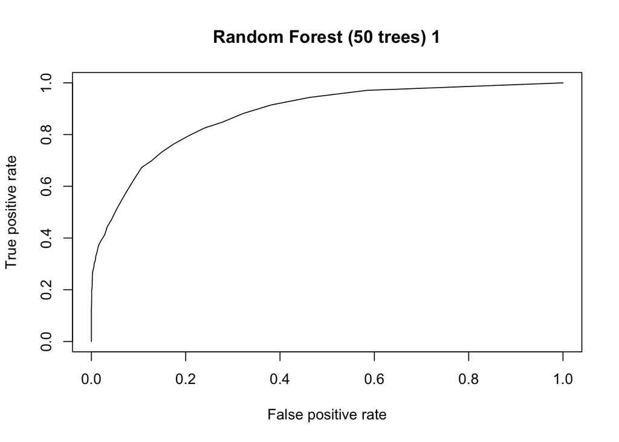

```r
pred4_rf <- prediction(phat4_prob_rf, adult_validation1$aw_over_50k)
plot(performance(pred4_rf, "tpr", "fpr"), main="Random Forest (50 trees) 1")
```

```r
performance(pred4_rf, "auc")@y.values[[1]]
```

```
## [1] 0.8786883
```

```r
#### tune the depth of the trees and the mtry
##### maxnodes=4, mtry=5
rf5 <- randomForest(adult_train1[,c(1:14)], adult_train1$aw_over_50k, ntree=50, maxnodes=4, mtry=5)
phat5_prob_rf <- predict(rf5, adult_validation1, type="prob")[,"1"]
table(ifelse(phat5_prob_rf > 0.5, 1, 0), adult_validation1$aw_over_50k)
```

```
##
##        0    1
##   0 3266  644
##   1  162  454
```

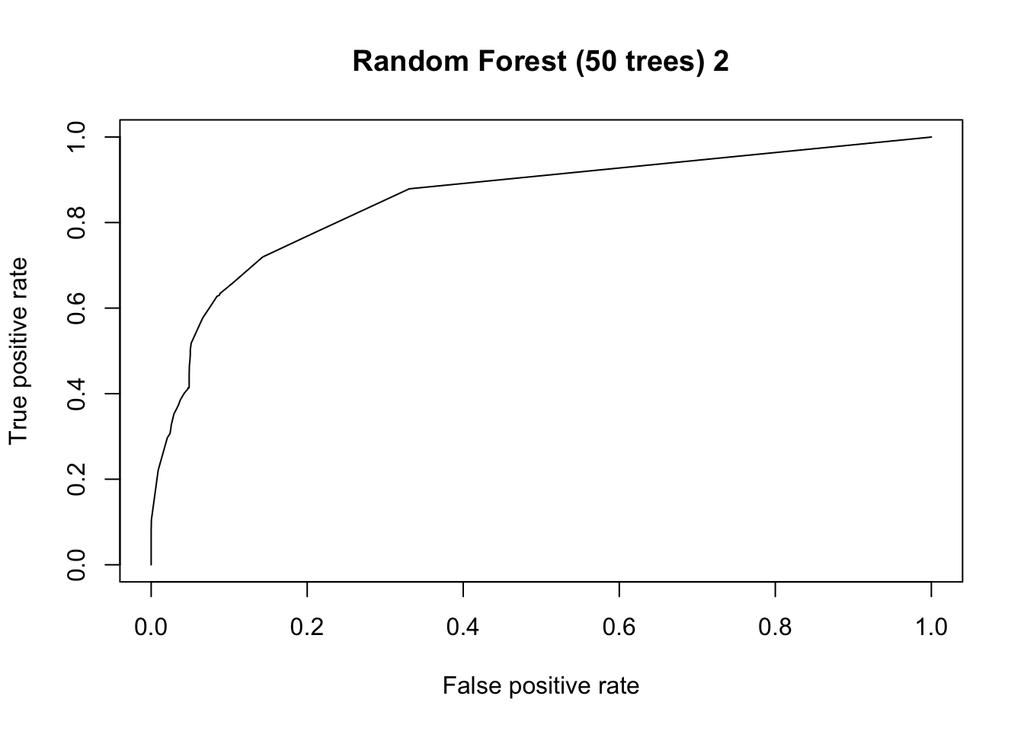

```r
pred5_rf <- prediction(phat5_prob_rf, adult_validation1$aw_over_50k)
plot(performance(pred5_rf, "tpr", "fpr"), main="Random Forest (50 trees) 2")
```

```r
performance(pred5_rf, "auc")@y.values[[1]]
```

```
## [1] 0.8533918
```

```r
##### maxnodes=3, mtry=2
rf6 <- randomForest(adult_train1[,c(1:14)], adult_train1$aw_over_50k, ntree=50, maxnodes=3, mtry=2)
phat6_prob_rf <- predict(rf6, adult_validation1, type="prob")[,"1"]
table(ifelse(phat6_prob_rf > 0.5, 1, 0), adult_validation1$aw_over_50k)
```

```
##
##        0    1
##   0 3428 1098
```

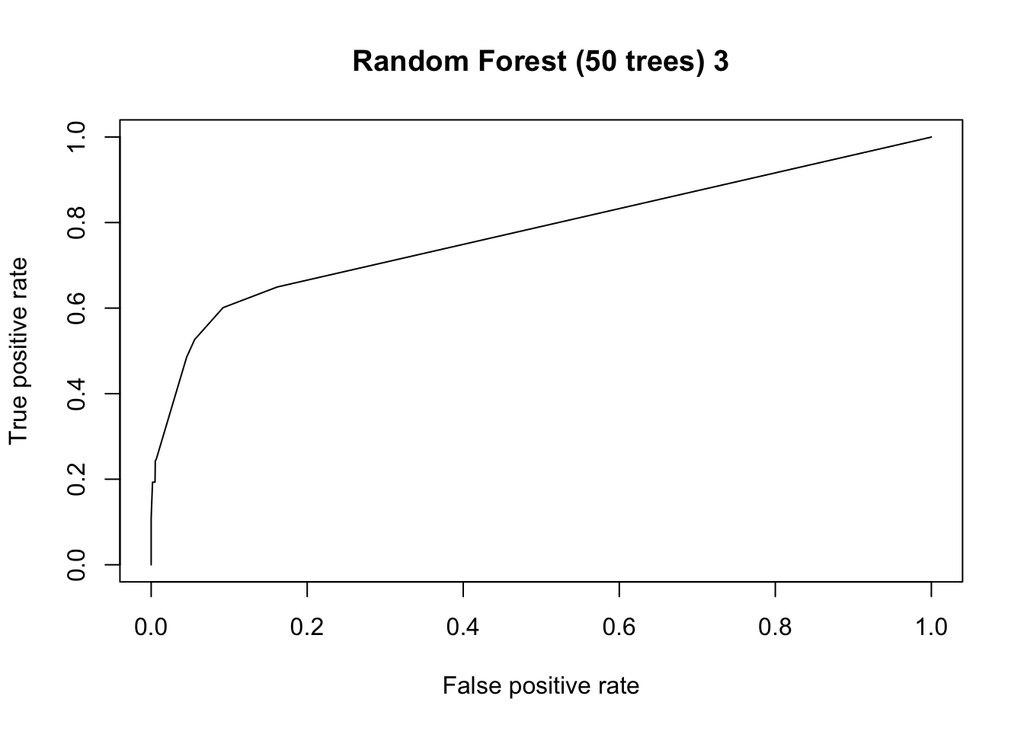

```r
pred6_rf <- prediction(phat6_prob_rf, adult_validation1$aw_over_50k)
plot(performance(pred6_rf, "tpr", "fpr"), main="Random Forest (50 trees) 3")
```

```r
performance(pred6_rf, "auc")@y.values[[1]]
```

```
## [1] 0.7760604
```

```r
### 100 trees
rf7 <- randomForest(adult_train1[,c(1:14)], adult_train1$aw_over_50k, ntree=100)
phat7_prob_rf <- predict(rf7, adult_validation1, type="prob")[,"1"]
table(ifelse(phat7_prob_rf > 0.5, 1, 0), adult_validation1$aw_over_50k)
```

```
##
##        0    1
##   0 3420  788
##   1    8  310
```

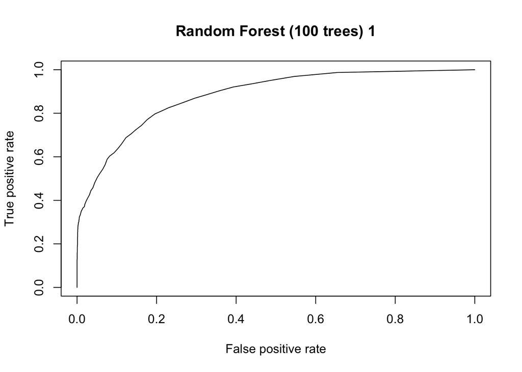

```r
pred7_rf <- prediction(phat7_prob_rf, adult_validation1$aw_over_50k)
plot(performance(pred7_rf, "tpr", "fpr"), main="Random Forest (100 trees) 1")
```

```r
performance(pred7_rf, "auc")@y.values[[1]]
```

```
## [1] 0.8822987
```

```r
#### tune the depth of the trees and the mtry
##### maxnodes=4, mtry=5
rf8 <- randomForest(adult_train1[,c(1:14)], adult_train1$aw_over_50k, ntree=100, maxnodes=4, mtry=5)
phat8_prob_rf <- predict(rf8, adult_validation1, type="prob")[,"1"]
table(ifelse(phat8_prob_rf > 0.5, 1, 0), adult_validation1$aw_over_50k)
```

```
##
##        0    1
##   0 3266  644
##   1  162  454
```

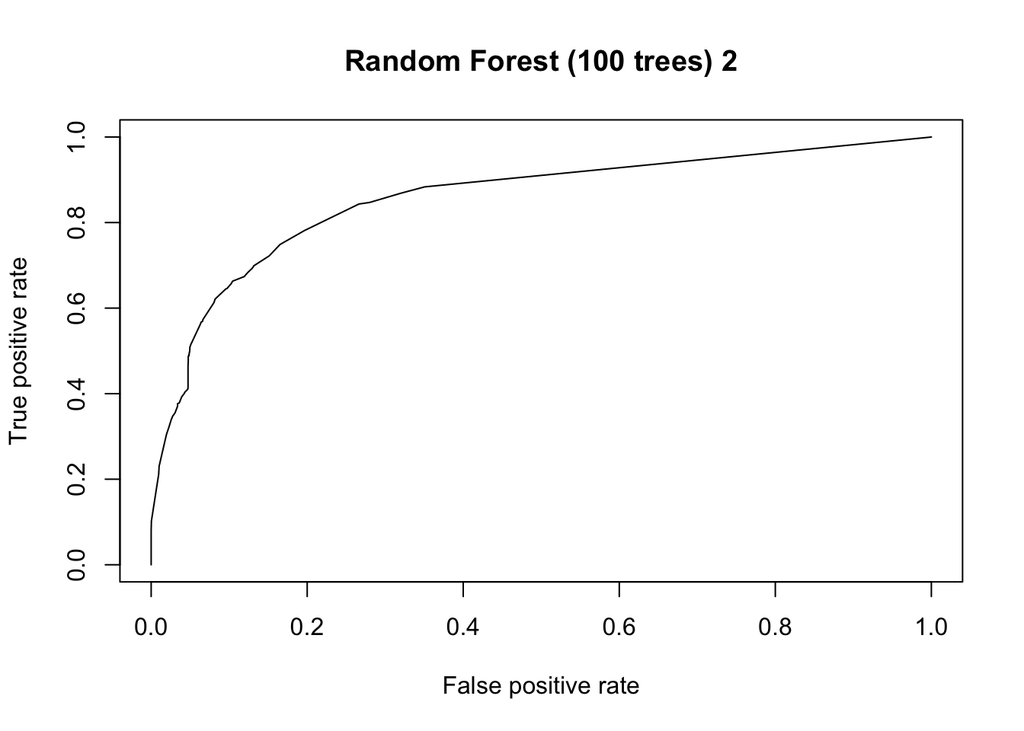

```r
pred8_rf <- prediction(phat8_prob_rf, adult_validation1$aw_over_50k)
plot(performance(pred8_rf, "tpr", "fpr"), main="Random Forest (100 trees) 2")
```

```r
performance(pred8_rf, "auc")@y.values[[1]]
```

```
## [1] 0.8556591
```

```r
##### maxnodes=3, mtry=2
rf9 <- randomForest(adult_train1[,c(1:14)], adult_train1$aw_over_50k, ntree=100, maxnodes=3, mtry=2)
phat9_prob_rf <- predict(rf9, adult_validation1, type="prob")[,"1"]
table(ifelse(phat9_prob_rf > 0.5, 1, 0), adult_validation1$aw_over_50k)
```

```
##
##        0    1
##   0 3428 1098
```

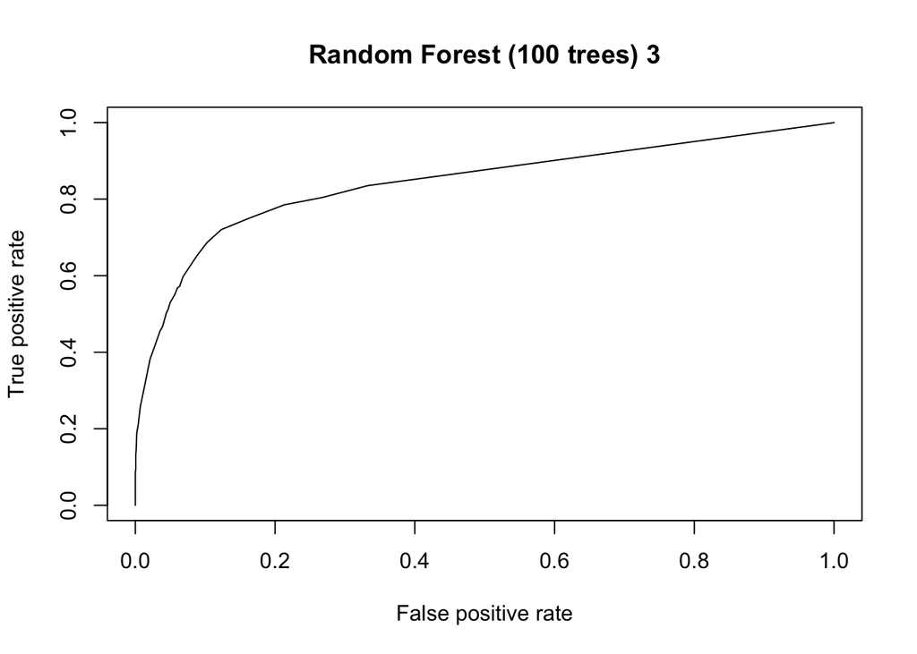

```r
pred9_rf <- prediction(phat9_prob_rf, adult_validation1$aw_over_50k)
plot(performance(pred9_rf, "tpr", "fpr"), main="Random Forest (100 trees) 3")
```

```r
performance(pred9_rf, "auc")@y.values[[1]]
```

```
## [1] 0.8425731
```

```r
## test data
### Using the validation data, we can tell the auc is the largest in model rf7. So we use the model rf7 to apply to the test data.
rf7_test <- randomForest(adult_train1[,c(1:14)], adult_train1$aw_over_50k, ntree=100)
phat7_prob_rf_test <- predict(rf7_test, adult_test1, type="prob")[,"1"]
table(ifelse(phat7_prob_rf_test > 0.5, 1, 0), adult_test1$aw_over_50k)
```

```
##
##        0    1
##   0 6751 1683
##   1   17  604
```

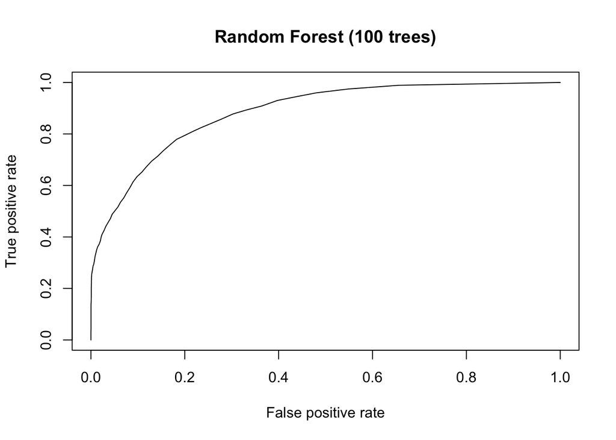

```r
pred7_rf_test <- prediction(phat7_prob_rf_test, adult_test1$aw_over_50k)
plot(performance(pred7_rf_test, "tpr", "fpr"), main="Random Forest (100 trees)")
```

```r
performance(pred7_rf_test, "auc")@y.values[[1]]
```

```
## [1] 0.8841605
```

```r
## FP, TP tradeoff: when false positive rate is small, true positive rate is also small. If we increase false positive rate, true positive rate will also increase. When false positive rate becomes 0.4, true positive rate can reach around 0.9 and this is a relatively reasonable level.

# use xgboost
library(xgboost)
adult_rf <- Matrix::sparse.model.matrix(aw_over_50k~.-1, data = adult)
adult_rf_train <- adult_rf[k,]
adult_rf_t <- adult_rf[-k,]
adult_rf_validation <- adult_rf_t[m,]
adult_rf_test <- adult_rf_t[-m,]
n_proc <- parallel::detectCores()
## 100 trees
rf_xgb1 <- xgboost(data=adult_rf_train, label=adult_train$aw_over_50k, nthread=n_proc, nround=1, max_depth=20, num_parallel_tree=100, subsample=0.632, colsample_bytree=1/sqrt(length(adult_rf_train@x)/nrow(adult_rf_train)), save_period=NULL)
phat_rf_xgb1 <- predict(rf_xgb1, newdata=adult_rf_validation)
rocr_pred_rf_xgb1 <- prediction(phat_rf_xgb1, adult_validation$aw_over_50k)
performance(rocr_pred_rf_xgb1, "auc")@y.values[[1]]
```

```
## [1] 0.8614071
```

```r
### change parameters
rf_xgb2 <- xgboost(data=adult_rf_train, label=adult_train$aw_over_50k, nthread=n_proc, nround=1, max_depth=30, num_parallel_tree=100, subsample=0.632, colsample_bytree=1/sqrt(length(adult_rf_train@x)/nrow(adult_rf_train)), save_period=NULL)
phat_rf_xgb2 <- predict(rf_xgb2, newdata=adult_rf_validation)
rocr_pred_rf_xgb2 <- prediction(phat_rf_xgb2, adult_validation$aw_over_50k)
performance(rocr_pred_rf_xgb2, "auc")@y.values[[1]]
```

```
## [1] 0.8564116
```